# Makine Öğrenmesi : Doğrusal Regresyon

[figure not shown]

Konuşmacılar:

**Onur Bilgiç**

**Sadık Ünal Çokünlü**

Tarih : **2019-11-09**

## Tek Değişkenli Doğrusal Regresyon

### Model Gösterimi

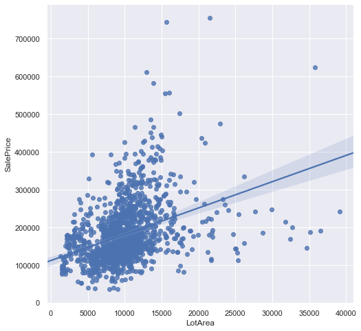

```python
cizdir()
```

**Gözetimli Öğrenme** : Verideki her bir örnek için doğru cevap verir.

**Regresyon problemi** : Gerçek değerli çıktıyı tahmin etmek.

**Sınıflandırma** : Kesikli değer çıktıları

### Notasyon

**x**: Girdi değişkenleri (Konut Boyutu)

**y**: Çıktı değişkeni ( Konut Fiyatı)

**$\theta$**: Katsayı

**h**: Hipotez (tahmin)

**(x, y)** – eğitim verisi

**x (i), y(i)** - i. eğitim verisi

```python
# (x) (y)
eğitim_verisi[["Konut_Boyutu","Konut_Fiyat"]].head(4)
```

|  | Konut_Boyutu | Konut_Fiyat |
| --- | --- | --- |
| 0 | 8450 | 208500 |
| 1 | 9600 | 181500 |
| 2 | 11250 | 223500 |
| 3 | 9550 | 140000 |

```python
eğitim_verisi.loc[0,["Konut_Boyutu","Konut_Fiyat"]] # x(0), y(0) # 0. index # not : Python'da index 0'dan başlar.
```

```
Konut_Boyutu      8450
Konut_Fiyat     208500
Name: 0, dtype: object
```

```python
x=eğitim_verisi["Konut_Boyutu"];x.head( )
```

```
0     8450
1     9600
2    11250
3     9550
4    14260
Name: Konut_Boyutu, dtype: int64
```

```python
y=eğitim_verisi["Konut_Fiyat"];y.head( )
```

```
0    208500
1    181500
2    223500
3    140000
4    250000
Name: Konut_Fiyat, dtype: int64
```

```python
m=y.shape[0];print("m :",m)
```

```
m : 1460
```

**$ \theta $ ve h'ı daha bilmiyoruz. Onları biz bulacağız.**

[figure not shown]

h'yi nasıl göstereceğiz ?

Hipotez : $h_0(x)= \theta_0 + \theta_1*x$

Tek değişkenli (univariate) doğrusal regresyon

```python
theta0=0; theta1=0.5; x=np.array([1,2,3]) ; h=theta0+theta1*x
```

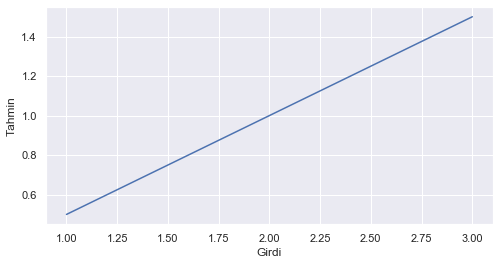

```python
cizdir()
```

```python
print("Girdiler(x):",x, ", Tahminler(h):",h);
```

```
Girdiler(x): [1 2 3] , Tahminler(h): [0.5 1.  1.5]
```

### Maliyet (bedel) Fonksiyonu

```python
# EĞİTİM VERİSİ
eğitim_verisi[["Konut_Boyutu","Konut_Fiyat"]].head(4)
```

|  | Konut_Boyutu | Konut_Fiyat |
| --- | --- | --- |
| 0 | 8450 | 208500 |
| 1 | 9600 | 181500 |
| 2 | 11250 | 223500 |
| 3 | 9550 | 140000 |

```python
eğitim_verisi.shape[0]  # m : Eğitim verisi sayısı
```

```
1460
```

Hipotez : $h_0(x)= \theta_0 + \theta_1*x$

"$\theta_i$" Katsayılar Nasıl Seçilecek ?

Durum 1: $\theta_0$ = 1.5 ve $\theta_1$ = 0

```python
## Durum 1
theta0=1.5 ;theta1=0 ; x=np.array([1,2,3]) ; h=theta0+theta1*x
```

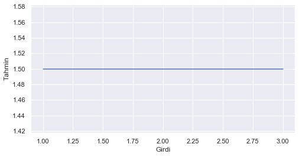

```python
cizdir()
```

```python
print("Girdiler(x):",x, ", Tahminler(h):",h)
```

```
Girdiler(x): [1 2 3] , Tahminler(h): [1.5 1.5 1.5]
```

Durum 2 : $\theta_0$ = 0 ve $\theta_1$ = 0.5

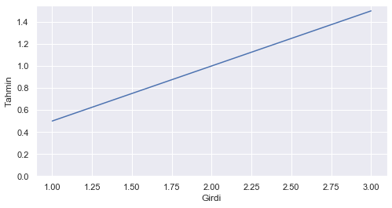

```python
## Durum 2
theta0=0 ;  theta1=0.5 ;   x=np.array([1,2,3]) ;   h=theta0+theta1*x
cizdir()
```

```python
print("Girdiler(x):",x, ", Tahminler(h):",h)
```

```
Girdiler(x): [1 2 3] , Tahminler(h): [0.5 1.  1.5]
```

Durum 3 : $\theta_0$ = 1 , $\theta_1$ = 0.5

```python
theta0=1 ;     theta1=0.5 ;    x=np.array([1,2,3]) ;    h=theta0+theta1*x
```

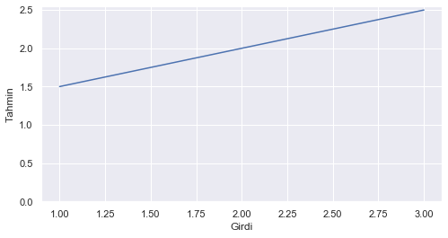

```python
cizdir()
```

```python
print("Girdiler(x):",x, ", Tahminler(h):",h)
```

```
Girdiler(x): [1 2 3] , Tahminler(h): [1.5 2.  2.5]
```

**Fikir : $ \theta_0 , \theta_1 $ öyle seçmeliyiz ki, $ h_0(x) $ eğitim verimiz(x,y) için y'ye yakın olmalıdır**

```python
theta0=0 ;   theta1=1 ;  x=np.array([0,1,2,3]) ;  y=np.array([0.2,1.15,1.8,3.3]) ;  h=theta0+theta1*x
```

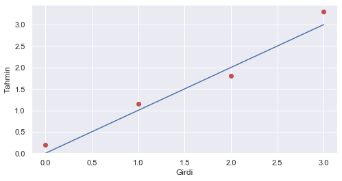

```python
cizdir()
```

```python
print("Girdiler(x):",x, ", Tahminler(h):",h)
```

```
Girdiler(x): [0 1 2 3] , Tahminler(h): [0 1 2 3]
```

### Maliyet (bedel) Fonksiyonu Çıkarım I

Hipotez : $h_0(x)= \theta_0 + \theta_1*x$

Katsayılar : $ \theta_0 , \theta_1 $

Bedel fonksiyonu : $ j=(1/2m)\sum\limits_{i=1}^{m} (h-y)^2 $

Amaç : $ minimize:J( \theta_0 , \theta_1) <- (\theta_0 , \theta_1) $

```python
# Yine
theta0=0 ; theta1= 1
```

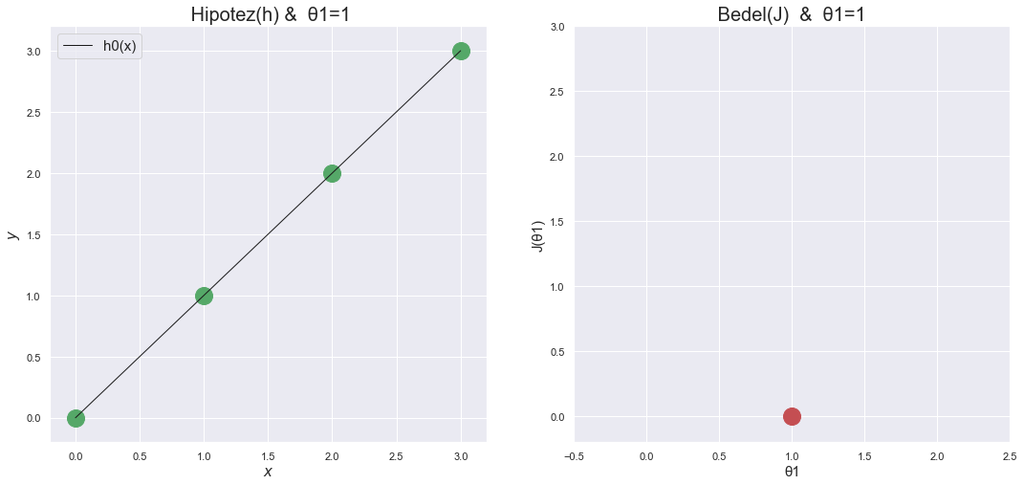

```python
cizdir()
```

```python
theta0=0;theta1= .5
```

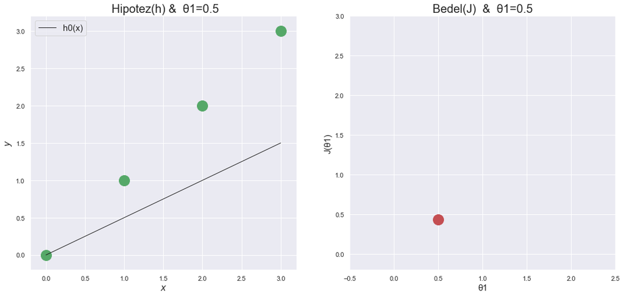

```python
cizdir()
```

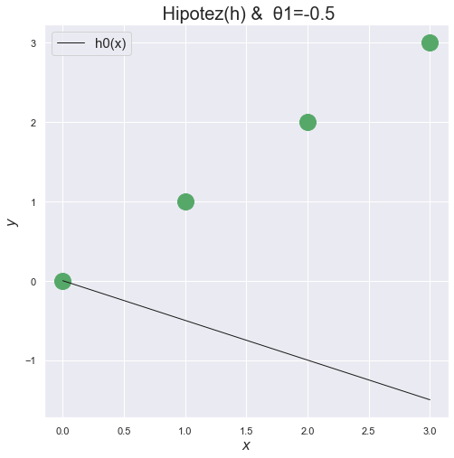

```python
cizdir()
```

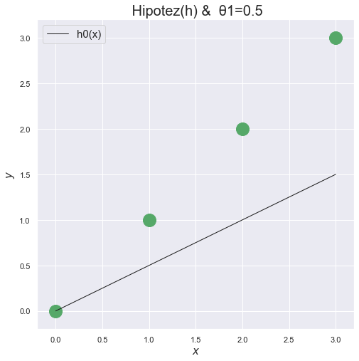

```python
cizdir()
```

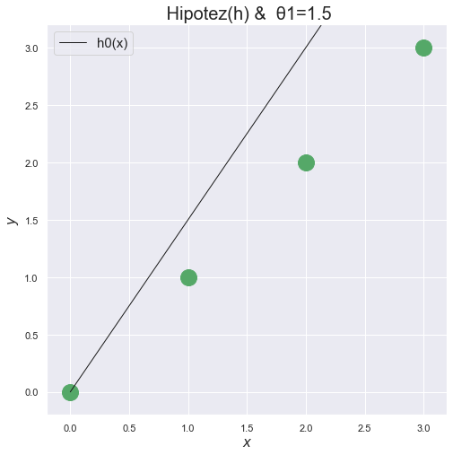

```python
cizdir()
```

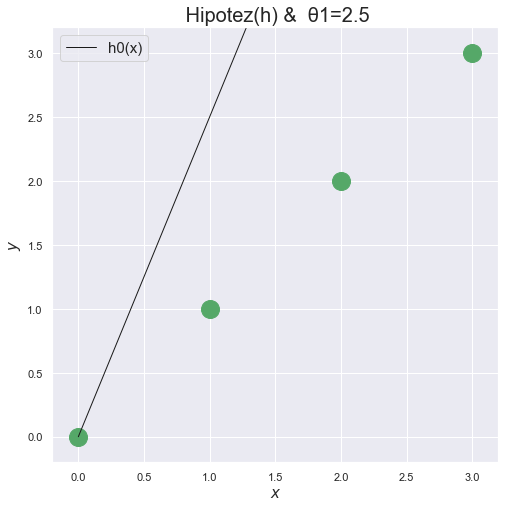

```python
cizdir()
```

En düşük bedel : $\theta_1$ = 1 için gerçekleşti.

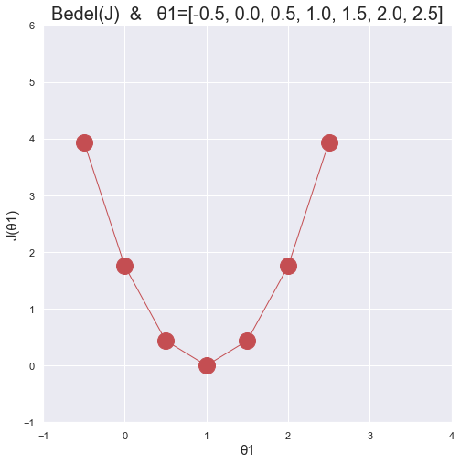

```python
cizdir()
```

### Maliyet (bedel) Fonksiyonu Çıkarım II

Hipotez : $h_0(x)= \theta_0 + \theta_1*x$

Katsayılar : $ \theta_0 , \theta_1 $

Bedel fonksiyonu : $ J_{(\theta_0 , \theta_1)}=(1/2m)\sum\limits_{i=1}^{m} (h_0(x^{(i)})-y^{(i)})^2 $

Amaç : $ minimize:J_{(\theta_0 , \theta_1)} $

$ \theta_0=50000$ , $\theta_1=12$ ve $h=50000+12*x$

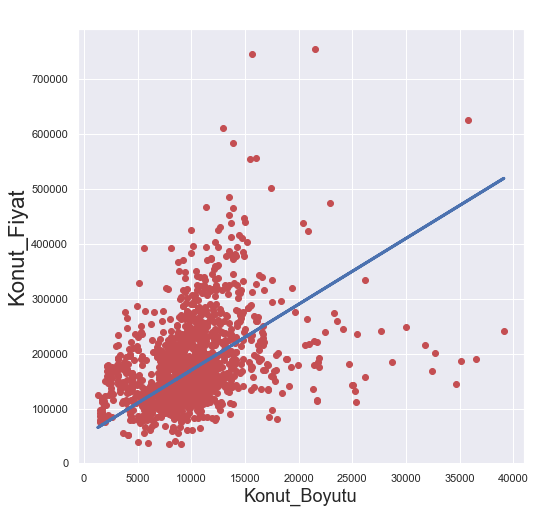

```python
cizdir()
```

```python
m=y.shape[0]

j=(1/(2*m))*np.sum(np.square(h-y)) # np.square karesini alır, np.sum hepsini toplar

print("Eğitim verisi adedi :{m}".format(m=m),"Bedel miktarı {bedel}".format(bedel=round(j,0)))
```

[output not shown]

[figure not shown]

```python
theta0=50000

theta1=12

h=theta0+theta1*x
```

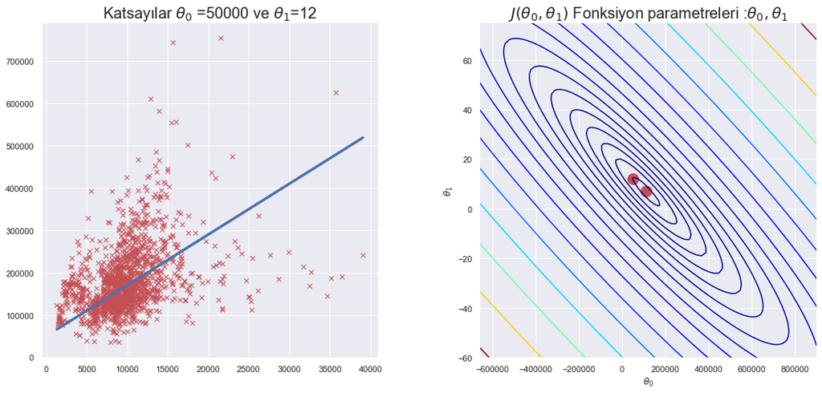

```python
cizdir()
```

### Dereceli Azaltma

Bir bedel fonskiyonumuz var. : $ J_{(\theta_0 , \theta_1)}$

İsteğimiz : $ minimize:J_{(\theta_0 , \theta_1)} $

Sonuç olarak :

Bazı $ \theta_0 , \theta_1 $ değerleri ile başla ve bunları değiştirerek $J_{(\theta_0 , \theta_1)} $'u düşürmeye devam et. $J_{(\theta_0 , \theta_1)} $ Minumum değerine ulaşana kadar bunu tekrarla.

[figure not shown]

### Dereceli Azaltma Algoritması

$j=0$ ve $j=1$ için yakınsayana kadar tekrar et :

\begin{equation}\ \theta_j := \theta_j-a*\frac{\partial J(\theta_0,\theta_1)}{\partial \theta_j} \end{equation}

Aynı anda $temp0=\theta_0$ ve $temp1=\theta_1$ atanır.

\begin{equation}\ temp0 := \theta_0-a*\frac{\partial J(\theta_0,\theta_1)}{\partial \theta_0} \end{equation}

\begin{equation}\ temp1 := \theta_1-a*\frac{\partial J(\theta_0,\theta_1)}{\partial \theta_1} \end{equation}

### Dereceli Azaltma Çıkarım

$ Öğrenme Hızı : a$

\begin{equation}\ \theta_j := \theta_j-a*\frac{\partial J(\theta_0,\theta_1)}{\partial \theta_j} \end{equation}

\begin{equation}\ Türev:\frac{\partial J(\theta_0,\theta_1)}{\partial \theta_j} \end{equation}

**Negatif eğim ve pozitif eğim nerelerdedir ?**

[figure not shown]

\begin{equation}\ A: \ 0<\frac{\partial J(\theta_0,\theta_1)}{\partial \theta_j} \end{equation}

\begin{equation}\ B: \ 0 >\frac{\partial J(\theta_0,\theta_1)}{\partial \theta_j} \end{equation}

\begin{equation}\ C: \ 0=\frac{\partial J(\theta_0,\theta_1)}{\partial \theta_j} \end{equation}

**Eğer α değeri çok küçük olursa, dereceli azalım çok yavaş olabilir.**

[figure not shown]

**Eğer α değeri çok büyük olursa, dereceli azalım minimumu aşabilir. Yakınsama, hatta ayrışma başarısız olabilir.**

[figure not shown]

\begin{equation}\ \theta_1 := \theta_1-a*\frac{\partial J(\theta_0,\theta_1)}{\partial \theta_1} \end{equation}

[figure not shown]

- Öğrenim hızı sabit olduğu halde dereceli azalma lokal minimuma yakınsayabilir.
- Lokal minumuma yaklaştıkca derece miktarı daha düşer.
- Bu küçük adımlara neden olur.
- Bu yüzden öğrenme hızını düşürmeye gerek yoktur.

[figure not shown]

### Doğrusal Regresyon için Dereceli Azaltma

$j=0$ ve $j=1$ için yakınsayana kadar tekrar et :

\begin{equation}\ \theta_j := \theta_j-a*\frac{\partial J(\theta_0,\theta_1)}{\partial \theta_j} \end{equation}

Doğrusal Regresyon Model :

$h_0(x)= \theta_0 + \theta_1*x$

Bedel fonksiyonu : $ J_{(\theta_0 , \theta_1)}=(1/2m)\sum\limits_{i=1}^{m} (h_0(x^{(i)})-y^{(i)})^2 $

\begin{equation}\ j=0 : \frac{\partial J(\theta_0,\theta_1)}{\partial \theta_0} =1/m \sum_{i=1}^m (h_\theta(x^{(i)})-y^{(i)})) \end{equation}

\begin{equation}\ j=1 : \frac{\partial J(\theta_0,\theta_1)}{\partial \theta_1} =1/m \sum_{i=1}^m (h_\theta(x^{(i)})-y^{(i)}))*x^{(i)} \end{equation}

Dereceli Azaltma Algoritması

$\theta_0$ ve $\theta_1$ yakınsayana kadar aynı anda güncellenir.

\begin{equation}\ \theta_0 := \theta_0-a*\frac{\partial J(\theta_0,\theta_1)}{\partial \theta_0} =1/m \sum_{i=1}^m (h_\theta(x^{(i)})-y^{(i)})) \end{equation}

\begin{equation}\ \theta_1 := \theta_1-a*\frac{\partial J(\theta_0,\theta_1)}{\partial \theta_1} =1/m \sum_{i=1}^m (h_\theta(x^{(i)})-y^{(i)}))*x^{(i)} \end{equation}

[figure not shown]

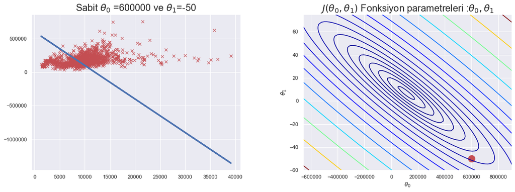

```python
cizdir()
```

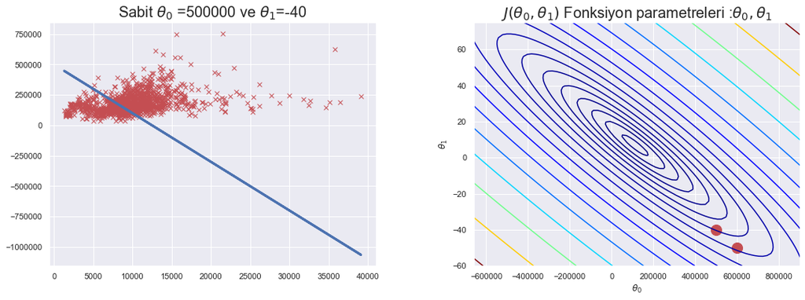

```python
cizdir()
```

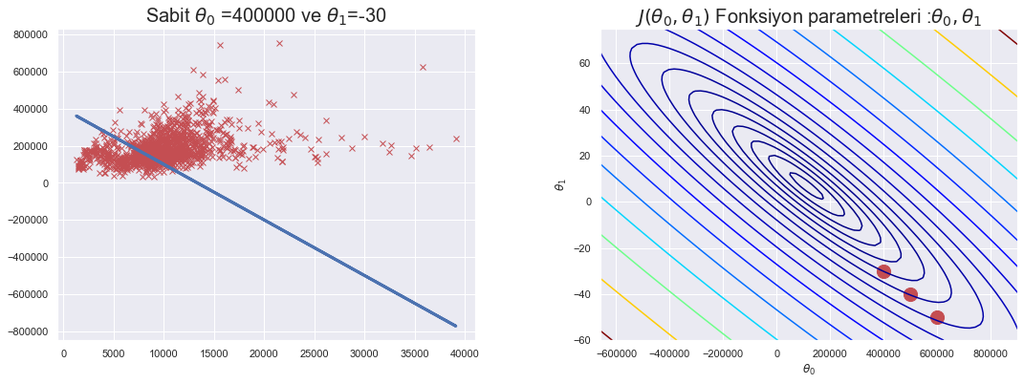

```python
cizdir()
```

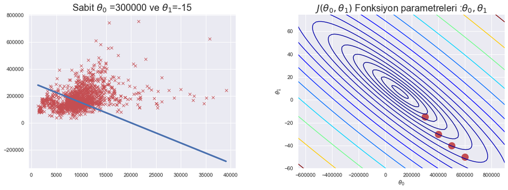

```python
cizdir()
```

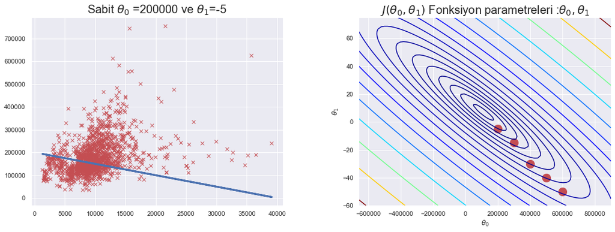

```python
cizdir()
```

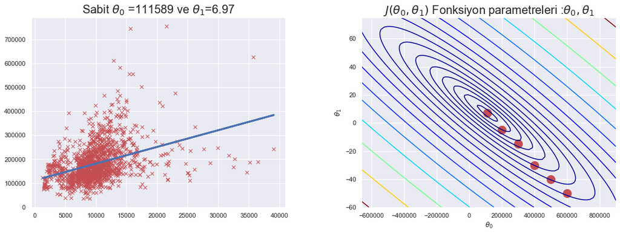

```python
cizdir()
```

### “Yığın” (Batch) Dereceli Azaltma Algoritması

“Yığın”: Her dereceli azaltma adımında tüm eğitim örnekleri kullanılır.

\begin{equation}\label{eq:} \sum\limits_{i=1}^{m} (h_0(x^{(i)}) -y^{(i)})^2 \end{equation}